# Herd Immunity - Graph Theory Edition

## By Jake Shams

# How can graph theory be applied?

- The original herd immunity is designed with an array of people who randomly interact with each other. This works, but it’s not so realistic.
- In using a graph we can create a network of people and have interactions based off proximity instead of complete randomness.
- So how do we create a realistic population?

# Creating the population

## How do we do it?

- Should edges be generated randomly?
- How should the number of people correlate to the number of connections?

### How should edges be generated?

- Randomly
- Clustering and cliques still occur when random edges are added.

### How should the number of people correlate to the number of connections?

- Linear?
- Exponential?
- Logarithmic!

## f(x) = log(10x)**2

```
(0, 10)
```

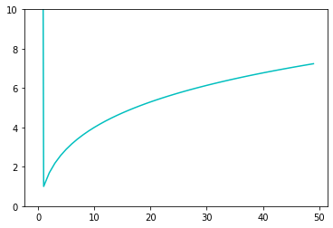

```python
plt.plot(log_func_50, 'c')
plt.ylim(0,10)
```

```
(0, 20)
```

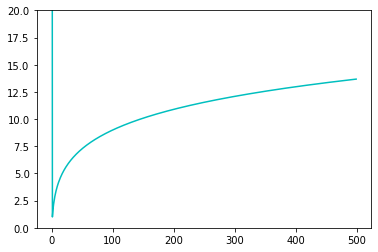

```python
plt.plot(log_func_500, 'c')
plt.ylim(0,20)
```

```
(0, 30)
```

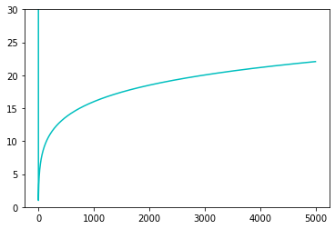

```python
plt.plot(log_func_5000, 'c')
plt.ylim(0,30)
```

#### This magical number is the average number of connections each person will have.

#### So total edges ≈ n (log(10n, 10)**2)

# Modeling interactions

- People are most likely to interact with other people in their first order network
- People can also interact with complete strangers, but odds are less likely.
- People can also interact with their second, third, etc. network.
- How?

### Find someone to interact with

- 20% chance a random person is chosen from the population.
- 60% chance a random person is chosen from one's first order network.
- 20% chance a random person is chosen from one's frist order network BUT we recursively call this function on them to return someone in your second order network.

# Algorithms

### Find the diameter of the population

### Find the most dangerous person in the population

### Find the most vulnerable person in the population

# Diameter

#### Longest shortest path

#### After many iterations I found that once population size passes 50 the diameter is always 4.

#### I have not been able to test for sizes greater than 200

# Most Dangerous Person

- Someone is dangerous if they can infect others.
- Someone is more dangerous than someone else if they can infect more people.
- To find the most dangerous person we have to first find out how dangerous everyone is.
- A person is only dangerous if they are alive and infected.
- A person's danger level is defined as their:
  - number of healthy unvaccinated neighbors / total number of neighbors + 0.2 * the sum of the dangers of neighbors.
- Look familiar?
- The method is based off our interaction method.

# Most Vulnerable Person

- Someone is vulnerable if they have friends that are infected.
- Someone is more vulnerable if they have more infected friends.
- To find the most vulnerable person we have to find how vulnerable everyone is.
- A person can only be vulnerable if they are healtly and unvaccinated.
- A person's vulnerability level is defined as the:
  - average of their neighbors' danger levels